# PeerAssessment1

timwilliate

August 15, 2014

#### Load the raw activity tracking dataset

```r
activityData <- read.csv("activity.csv")
activityData_noNA <- subset(activityData, steps != 'NA')
```

#### Section 1: What is the mean total number of steps taken per day?

Compute and plot a histogram of the total step count per day:

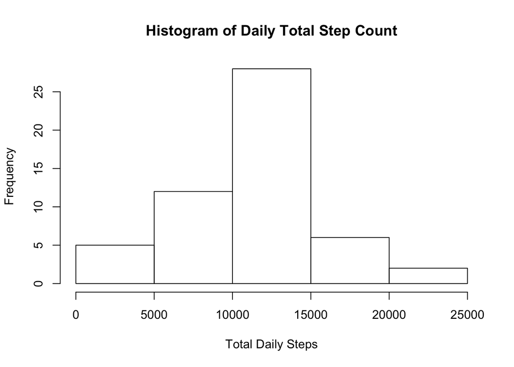

```r
dailyTotalSteps <- aggregate(steps~date, activityData_noNA, sum)
hist(dailyTotalSteps$steps, main = ("Histogram of Daily Total Step Count"), xlab = "Total Daily Steps", freq = TRUE)
```

The mean daily step count is:

```r
mean(dailyTotalSteps$steps)
```

```
## [1] 10766
```

The median daily step count is:

```r
median(dailyTotalSteps$steps)
```

```
## [1] 10765
```

#### Section 2: What is the average daily activity pattern?

Make a time series plot of the mean number of steps taken as fuction of 5-minute measurement interval:

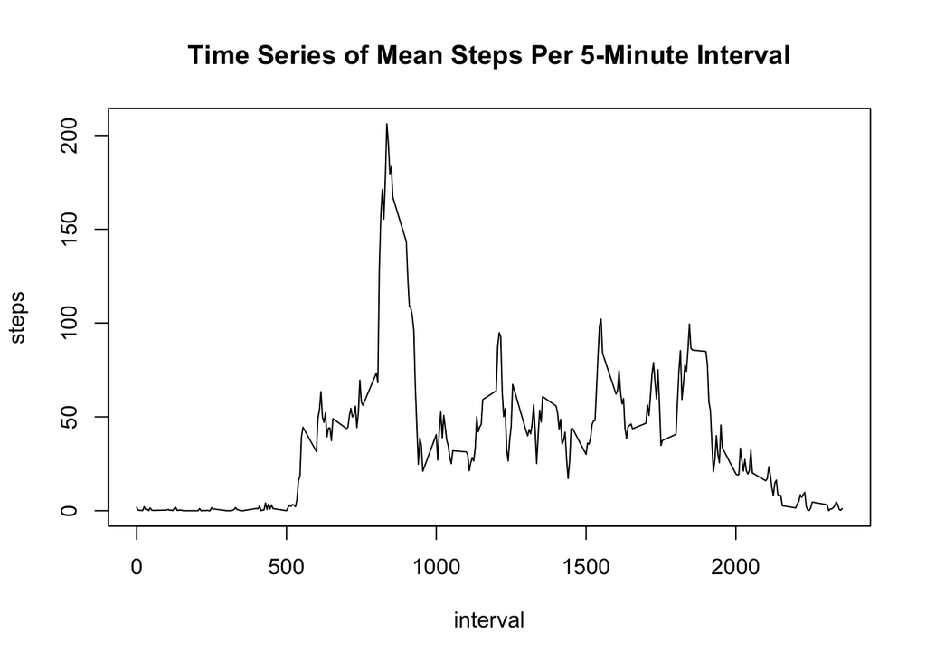

```r
meanStepsPerInterval <- aggregate(steps~interval, activityData_noNA, mean)
plot(meanStepsPerInterval, type = 'l', main = ("Time Series of Mean Steps Per 5-Minute Interval"))
```

Which 5-minute interval, on average across all the days in the dataset, contains the maximum number of steps?

```r
subset(meanStepsPerInterval, steps == max(meanStepsPerInterval[,2]))
```

```
##     interval steps
## 104      835 206.2
```

#### Section 3: Imputing missing values

Calculate and report the total number of missing values in the dataset (i.e. the total number of rows with NAs)

```r
nMissingValues <- nrow(activityData) - nrow(activityData_noNA)
nMissingValues
```

```
## [1] 2304
```

Devise a strategy for filling in all of the missing values in the dataset. Below I chose to fill in missing values using the mean step count recorded over the entire set of equivalent 5-minute intervals:

```r
library(plyr)
rowsWithNA <- subset(activityData, is.na(steps) == TRUE)
estimateByMeans <- join(rowsWithNA, meanStepsPerInterval, by = "interval", type = "left")
interpolatedDataSet <- rbind(activityData_noNA, estimateByMeans[,2:4])
head(interpolatedDataSet)
```

```
##     steps       date interval
## 289     0 2012-10-02        0
## 290     0 2012-10-02        5
## 291     0 2012-10-02       10
## 292     0 2012-10-02       15
## 293     0 2012-10-02       20
## 294     0 2012-10-02       25
```

Compute and plot a histogram of the total step count per day:

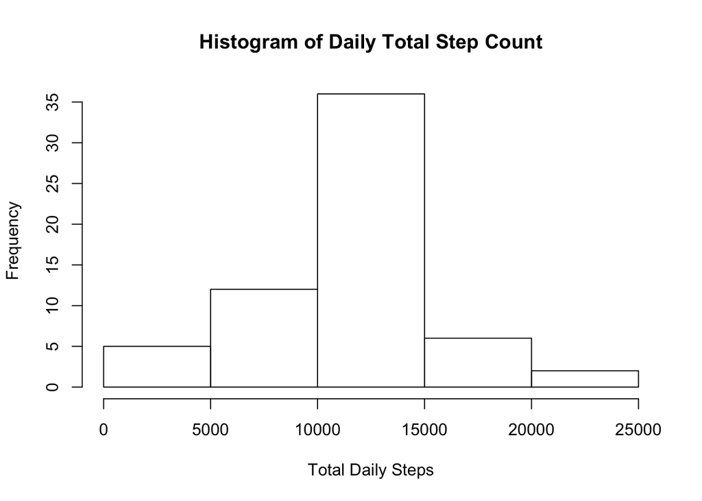

```r
dailyTotalStepsInterpolated <- aggregate(steps~date, interpolatedDataSet, sum)
hist(dailyTotalStepsInterpolated$steps, main = ("Histogram of Daily Total Step Count"), xlab = "Total Daily Steps", freq = TRUE)
```

The mean daily step count is:

```r
mean(dailyTotalStepsInterpolated$steps)
```

```
## [1] 10766
```

The median daily step count is:

```r
median(dailyTotalStepsInterpolated$steps)
```

```
## [1] 10766
```

Imputing the missing values does not change the mean value of the daily step count from the previous estiamte. The median daily step count changed by only a single step. Overall the impact of imputing the missing values is neglible when measured at the level of mean and meadian daily step counts.

#### Section 4: Are there differences in activity patterns between weekdays and weekends?

Create a new factor variable in the dataset with two levels – “weekday” and “weekend” indicating whether a given date is a weekday or weekend day:

```r
library(lubridate)
interpolatedDataSet$date <- ymd(interpolatedDataSet$date)

classifyDate <- function(date) {
  if (weekdays(date) == "Saturday")  {"weekend"}
  else if (weekdays(date) == "Sunday") {"weekend"}
  else {"weekday"}
  }

interpolatedDataSet$wday <- lapply(interpolatedDataSet$date, classifyDate)
interpolatedDataSet$wday <- as.factor(unlist(interpolatedDataSet$wday))
```